# Getting started with bayesSYNC: a simulated biomarker example

bayesSYNC

```r
library(bayesSYNC)
```

## What this vignette shows

`bayesSYNC` implements a Bayesian functional factor model for high-dimensional longitudinal data. It represents many observed curves (for example biomarker trajectories) through a small number of shared, time-varying latent factors that can be read as coordinated biological programmes or pathways. Each factor loads on a subset of biomarkers through a sparse loading matrix, and its temporal shape is described by functional principal component analysis (FPCA), which splits within-factor variation into orthogonal modes ordered by the variance they explain. Subject heterogeneity enters through low-dimensional FPCA scores. The method is described in Jaoua, Temko and Ruffieux (2026), *A scalable Bayesian functional factor model for high-dimensional longitudinal molecular data*, [arXiv:2603.20844](https://arxiv.org/abs/2603.20844); section numbers below refer to that paper.

This tutorial runs the whole workflow on a small simulated dataset, so every estimate can be checked against a known truth. We use `generate_bayesSYNC_data()` to produce the curves, then fit the model with a deliberately over-specified number of factors and components and let the sparsity-inducing priors reveal how many are actually supported by the data. This mirrors the recommended practice of inferring the effective number of factors by over-specification (Section 4.3).

We follow `N` patients over time `t`, measuring `p` biomarkers at a handful of irregular visits per patient. The model works on normalised time, so `t` must lie in `[0, 1]`; Section 5 shows how to rescale an arbitrary time range and map the results back. Here `p = 10` is a deliberately small toy so the vignette runs quickly, but the method scales far beyond this: it has been applied to data with up to 20,000 variables, matching the order of the number of human genes. Building this vignette fits the over-specified model and takes a few minutes.

## 1. Simulate the data

`generate_bayesSYNC_data()` takes a mean function with signature `mu_func(t, j, p)`, the numbers of subjects, biomarkers, factors and components, and a per-subject count of visits. The Beta parameters `a_om` and `b_om` control how many biomarkers load on each factor: the default `b_om = p` is very sparse, so here we use a denser setting that gives each factor a clear block of loading biomarkers, which keeps the illustration easy to read.

```r
set.seed(1)

N <- 50                 # patients
p <- 10                  # biomarkers
Q_true <- 2              # true latent factors
L_true <- 2              # true FPCA components per factor

# mean function: note the required (t, j, p) signature
mu_func <- function(t, j, p) 1.5 * j + sin(2 * pi * t + j)

n_visits <- sample(3:10, N, replace = TRUE)   # irregular number of visits per patient

sim <- generate_bayesSYNC_data(
  N = N, n = n_visits, p = p, Q = Q_true, L = L_true,
  mu_func = mu_func,
  a_om = 5, b_om = 2,          # dense loadings: many biomarkers load on each factor
  vec_sd_zeta = c(1, 0.5),     # mode 1 carries more variance than mode 2
  vec_sd_eps = 0.2,            # measurement-noise standard deviation
  seed = 1
)

time_obs <- sim$time_obs
Y        <- sim$Y

# how many biomarkers actually load on each true factor
colSums(sim$gamma)
```

```
#> [1] 7 8
```

The outputs `Y` and `time_obs` are already in the format `bayesSYNC()` expects: `Y[[i]][[j]]` holds patient `i`’s biomarker `j`, measured at the times in `time_obs[[i]]`.

## 2. Fit an over-specified model

We deliberately ask for more factors and modes than the truth (`Q = 5`, `L = 5`) and let the model prune what it does not need, following the over-specification strategy for learning the number of factors (Section 4.3). `bool_scale = FALSE` because the biomarkers already share a comparable residual scale; `set_hyper(d_0 = 1)` gives a neutral inclusion prior. We keep the default `maxit = 1000`. This is the heaviest step of the vignette because the cost grows with `Q` and `L`; lower them for quicker iteration.

```r
Q_fit <- 5
L_fit <- 5

fit <- bayesSYNC(time_obs = time_obs, Y = Y, L = L_fit, Q = Q_fit,
                 bool_scale = FALSE, list_hyper = set_hyper(d_0 = 1),
                 n_cpus = 1,
                 tol_abs = 1e-3, tol_rel = 1e-4,   # tol_rel loosened so it converges within maxit
                 seed = 1, verbose = FALSE)
```

```
#> == Seed set to 1 ==
```

```r
cat("iterations run:", fit$i_iter, "\n")
```

```
#> iterations run: 209
```

## 3. How many factors and modes are supported?

Two quantities drive the selection. The factor-level posterior probability of inclusion `factor_ppi` gives, for each of the five fitted factors, the probability that at least one biomarker contributes to it. We keep the factors whose activity is high and treat the rest as empty. Within each retained factor, the cumulated percentage of variance explained across its FPCA modes tells us how many modes are needed; the remaining modes carry negligible variance.

```r
# (a) retain factors by their activity
round(fit$factor_ppi, 3)
```

```
#> Factor_1 Factor_2 Factor_3 Factor_4 Factor_5
#>        0        0        1        0        1
```

```r
active <- which(fit$factor_ppi > 0.5)
cat("retained factors:", length(active), "( expected", Q_true, ")\n")
```

```
#> retained factors: 2 ( expected 2 )
```

```r
# (b) within each retained factor, number of modes reaching 99% of the variance
n_modes <- sapply(fit$list_cumulated_pve[active],
                  function(cp) which(cp >= 99)[1])
n_modes                                   # expected 2 for each retained factor
```

```
#> factor_3 factor_5
#>        2        2
```

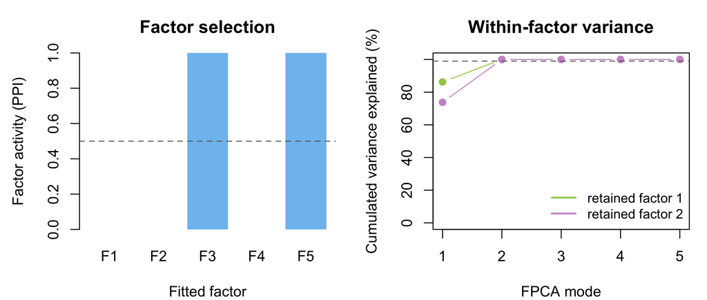

```r
op <- par(mfrow = c(1, 2), mar = c(4, 4.5, 3, 1))

barplot(fit$factor_ppi, names.arg = paste0("F", 1:Q_fit),
        ylim = c(0, 1), col = "skyblue2", border = NA,
        xlab = "Fitted factor", ylab = "Factor activity (PPI)",
        main = "Factor selection")
abline(h = 0.5, lty = 2, col = "grey40")

# cumulated variance explained within the retained factors
cp_mat <- sapply(fit$list_cumulated_pve[active], function(cp) cp[1:L_fit])
matplot(1:L_fit, cp_mat, type = "b", pch = 19, lty = 1,
        col = c("darkolivegreen3", "plum3"), ylim = c(0, 100),
        xlab = "FPCA mode", ylab = "Cumulated variance explained (%)",
        main = "Within-factor variance")
abline(h = 99, lty = 2, col = "grey40")
legend("bottomright", paste("retained factor", seq_along(active)),
       col = c("darkolivegreen3", "plum3"), lwd = 2, bty = "n", cex = 0.9)
```

```r
par(op)
```

The left panel shows two factors clearly above the activity threshold and three near zero, recovering `Q_true = 2`. The right panel shows the cumulated variance climbing to essentially 100% by the second mode, recovering `L_true = 2`.

Once the factors are retained, `fit$factor_pve` gives the proportion of variance explained by each of them. `total` is each factor’s share of the variance of the retained factors plus the measurement error, so these values sum to less than one; `structured` leaves out the measurement error and sums to one. Both are derived from the fitted model rather than computed as an R² against the data, and factors that are not retained are `NA`. `get_factor_pve()` recomputes them with other settings, for instance to include all factors.

```r
round(fit$factor_pve$total, 3)
```

```
#> Factor_1 Factor_2 Factor_3 Factor_4 Factor_5
#>       NA       NA    0.598       NA    0.372
```

```r
round(fit$factor_pve$structured, 3)
```

```
#> Factor_1 Factor_2 Factor_3 Factor_4 Factor_5
#>       NA       NA    0.616       NA    0.384
```

## 4. Align the estimates to the truth

Latent factors are identified only up to order, sign and an overall loading/score scale, so before comparing estimates with the simulation we align them. `match_factor_and_sign()` uses the true loadings and scores to permute the fitted factors, keep the `Q_true` that match, flip signs and rescale. On real data there is no truth to align to: you would stop at Section 3 and interpret the retained factors directly.

```r
aligned <- match_factor_and_sign(
  B = sim$B, B_hat = fit$B_hat, ppi = fit$ppi, factor_ppi = fit$factor_ppi,
  Zeta = sim$Zeta, list_Zeta_hat = fit$list_Zeta_hat,
  list_list_Phi_hat = fit$list_list_Phi_hat,
  list_cumulated_pve = fit$list_cumulated_pve,
  list_Cov_zeta_hat = fit$list_Cov_zeta_hat
)
B_hat_al    <- aligned$perm_B_hat              # p x Q_true
Phi_hat_al  <- aligned$perm_list_list_Phi_hat  # list of Q_true, grid x L_fit
Zeta_hat_al <- aligned$perm_list_Zeta_hat      # list of Q_true, N x L_fit
pve_al      <- aligned$perm_list_cumulated_pve

# true and estimated loadings side by side. We rename the columns so the two
# blocks are unambiguous: the fitted factors keep their original labels (e.g.
# Factor_4, Factor_5) after selection, which do not match the true factor order.
B_true <- sim$B
rownames(B_true) <- rownames(B_hat_al) <- as.character(1:p)
colnames(B_hat_al) <- paste0("est_F", 1:Q_true)
colnames(B_true)   <- paste0("true_F", 1:Q_true)
round(cbind(B_hat_al, B_true), 2)
```

```
#>    est_F1 est_F2 true_F1 true_F2
#> 1   -0.39   0.00   -0.37    0.00
#> 2    0.32   1.89    0.32    1.88
#> 3    0.00  -0.94    0.00   -0.93
#> 4    0.00  -0.29    0.00   -0.29
#> 5    1.67  -0.65    1.68   -0.61
#> 6    0.78   0.00    0.78    0.00
#> 7    0.72   0.57    0.71    0.60
#> 8   -0.55  -1.51   -0.54   -1.52
#> 9   -0.03  -0.20    0.00   -0.21
#> 10  -0.36  -0.57   -0.35   -0.57
```

## Results: recovering the shared temporal structure

The five panels below compare the fit (blue) with the simulated truth (black). Together they show that the model recovers, from noisy and irregularly sampled curves, the four ingredients of the generative model: the biomarker trajectories themselves, which biomarkers drive each factor, the temporal shape of each factor, and where each subject sits along those shapes.

```r
time_g  <- fit$time_g
col_sim <- "black"
col_est <- "skyblue2"

# true noise-free curve for patient i, biomarker j, on the dense grid
true_curve_g <- function(i, j) {
  val <- sim$mu_g[[j]]
  for (q in 1:Q_true) {
    val <- val + sim$B[j, q] * as.vector(sim$Phi_g[[q]] %*% sim$Zeta[[q]][i, ])
  }
  val
}
```

### Reconstructed biomarker trajectories

Each panel is one patient and one biomarker. The blue curve is the fitted trajectory with its pointwise 95% prediction band; the grey dots are the actual (noisy) observations; the black curve is the noise-free truth. The band includes the measurement error, so it is an interval for new observations rather than for the noise-free curve, and it should contain most of the observed points. The fit should track the truth even where visits are sparse, because the model borrows strength across subjects and biomarkers.

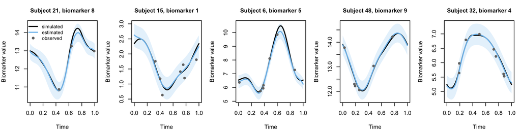

```r
set.seed(2)
pairs_i <- sample(1:N, 5)
pairs_j <- sample(1:p, 5)
op <- par(mfrow = c(1, 5), mar = c(4, 4, 3, 1), cex.main = 1)
for (k in 1:5) {
  i <- pairs_i[k]; j <- pairs_j[k]
  yh <- fit$list_Y_hat[[i]][[j]]; yl <- fit$list_Y_low[[i]][[j]]; yu <- fit$list_Y_upp[[i]][[j]]
  yt <- true_curve_g(i, j)
  plot(time_g, yh, type = "n", ylim = range(c(yl, yu, Y[[i]][[j]], yt)),
       xlab = "Time", ylab = "Biomarker value",
       main = sprintf("Subject %d, biomarker %d", i, j))
  polygon(c(time_g, rev(time_g)), c(yl, rev(yu)), col = adjustcolor(col_est, 0.2), border = NA)
  lines(time_g, yt, lwd = 2, col = col_sim)
  lines(time_g, yh, lwd = 2, col = col_est)
  points(time_obs[[i]], Y[[i]][[j]], pch = 19, col = "grey45", cex = 0.8)
  if (k == 1) legend("topleft", c("simulated", "estimated", "observed"),
                     col = c(col_sim, col_est, "grey45"), lwd = c(2, 2, NA),
                     pch = c(NA, NA, 19), bty = "n", cex = 0.85)
}
```

```r
par(op)
```

### Loading matrix: which biomarkers drive each factor

The loading matrix is the map from biomarkers (rows) to factors (columns). A strongly coloured cell means the biomarker contributes to that factor, red for a positive loading and blue for a negative one; near-white rows are biomarkers the factor ignores. This sparse structure is what makes each factor interpretable as a pathway acting on a specific subset of biomarkers. The left panel is the truth; the right panel is the estimate, annotated with the sign of the true loading so position and sign can be checked at a glance.

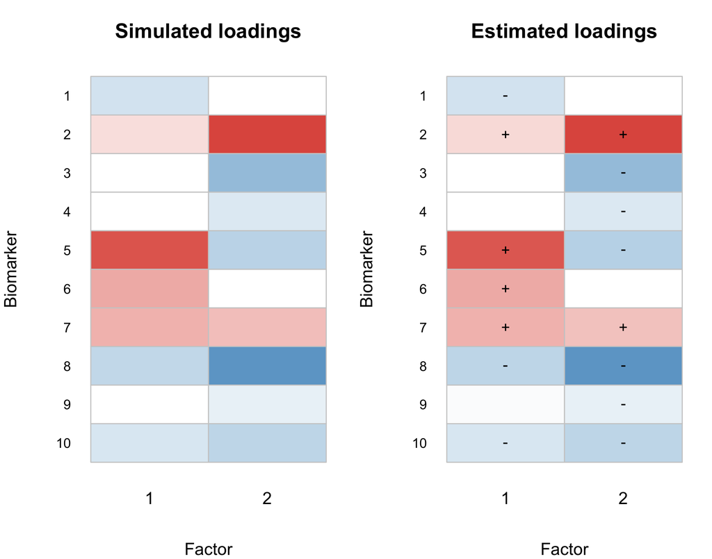

```r
plot_loading_matrix <- function(M, main = "", sign_annot = NULL) {
  M[!is.finite(M)] <- 0
  pn <- nrow(M); qn <- ncol(M)
  m <- max(abs(M)); if (!is.finite(m) || m == 0) m <- 1
  pal <- colorRampPalette(c("#4a90c2", "white", "#e05a4d"))(101)
  v2c <- function(v) { if (!is.finite(v)) v <- 0; pal[round((v + m) / (2 * m) * 100) + 1] }
  plot(NA, xlim = c(0.5, qn + 0.5), ylim = c(0.5, pn + 0.5),
       xlab = "Factor", ylab = "Biomarker", axes = FALSE, main = main)
  for (j in 1:pn) { yv <- pn - j + 1; for (q in 1:qn) {
    rect(q - 0.5, yv - 0.5, q + 0.5, yv + 0.5, col = v2c(M[j, q]), border = "grey80")
    if (!is.null(sign_annot) && sign_annot[j, q] != "") text(q, yv, sign_annot[j, q], cex = 0.9)
  }}
  axis(1, at = 1:qn, labels = 1:qn, tick = FALSE, line = -0.5)
  axis(2, at = pn:1, labels = 1:pn, las = 1, tick = FALSE, line = -0.5, cex.axis = 0.8)
}
true_sign <- matrix("", p, Q_true); true_sign[B_true > 0] <- "+"; true_sign[B_true < 0] <- "-"
op <- par(mfrow = c(1, 2), mar = c(4, 4, 3, 1))
plot_loading_matrix(B_true,   main = "Simulated loadings")
plot_loading_matrix(B_hat_al, main = "Estimated loadings", sign_annot = true_sign)
```

```r
par(op)
```

### Eigenfunctions: the temporal shape of each factor

Within a factor, FPCA decomposes the subject curves into orthogonal modes ordered by the variance they explain. Each panel is one mode of one factor: the black curve is the true eigenfunction, the blue curve the estimate, and the title gives the share of within-factor variance carried by that mode. Mode 1 captures the dominant temporal pattern, mode 2 a smaller higher-order fluctuation.

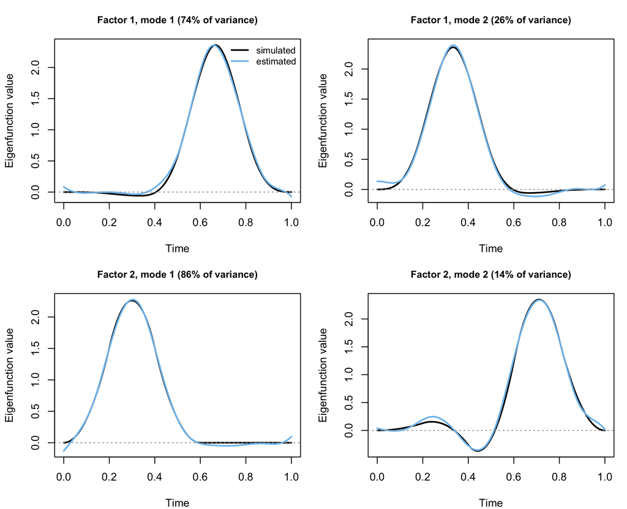

```r
per_comp_pve <- function(cp) c(cp[1], diff(cp))
op <- par(mfrow = c(Q_true, L_true), mar = c(4, 4.2, 3, 1), cex.main = 0.9)
for (q in 1:Q_true) {
  pv <- per_comp_pve(pve_al[[q]])
  for (l in 1:L_true) {
    yl <- range(c(sim$Phi_g[[q]][, l], Phi_hat_al[[q]][, l]))
    plot(time_g, sim$Phi_g[[q]][, l], type = "l", lwd = 2, col = col_sim, ylim = yl,
         xlab = "Time", ylab = "Eigenfunction value",
         main = sprintf("Factor %d, mode %d (%.0f%% of variance)", q, l, pv[l]))
    lines(time_g, Phi_hat_al[[q]][, l], lwd = 2, col = col_est)
    abline(h = 0, lty = 3, col = "grey60")
    if (q == 1 && l == 1) legend("topright", c("simulated", "estimated"),
                                 col = c(col_sim, col_est), lwd = 2, bty = "n", cex = 0.85)
  }
}
```

```r
par(op)
```

### Scores: where each subject sits along each mode

The score places each subject on a given factor and mode: it is the weight of that subject’s curve on the corresponding eigenfunction, and it is where patient heterogeneity is summarised. Each panel plots the estimated score against the true score across subjects, for one factor and mode. A tight straight line means the ordering and spread of subjects are recovered. The axes need not share a scale, since loadings and scores are identified only up to a common factor, so we report the correlation and a best-fit line.

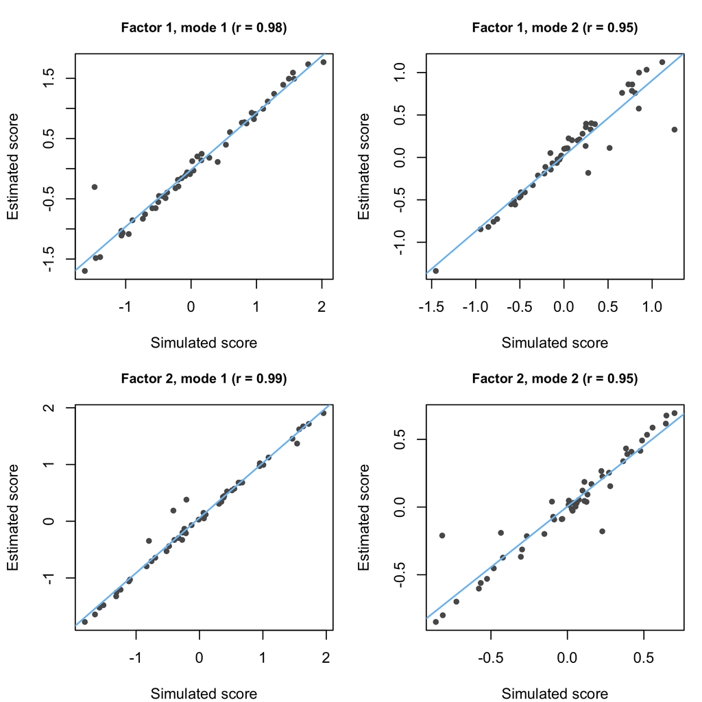

```r
op <- par(mfrow = c(Q_true, L_true), mar = c(4, 4.2, 3, 1), cex.main = 0.9)
for (q in 1:Q_true) for (l in 1:L_true) {
  xs <- sim$Zeta[[q]][, l]; ys <- Zeta_hat_al[[q]][, l]
  ok <- sd(xs) > 0 && sd(ys) > 0
  plot(xs, ys, pch = 19, col = "grey35", cex = 0.7,
       xlab = "Simulated score", ylab = "Estimated score",
       main = sprintf("Factor %d, mode %d (r = %s)", q, l,
                      ifelse(ok, sprintf("%.2f", cor(xs, ys)), "NA")))
  if (ok) abline(lm(ys ~ xs), col = col_est, lwd = 1.5)
}
```

```r
par(op)
```

### Mean functions

Separately from the factors, each biomarker has its own population mean trajectory. Each panel overlays the true mean (black) and the estimated mean (blue) for one biomarker. These should match closely, since the mean is the easiest part of the model to estimate.

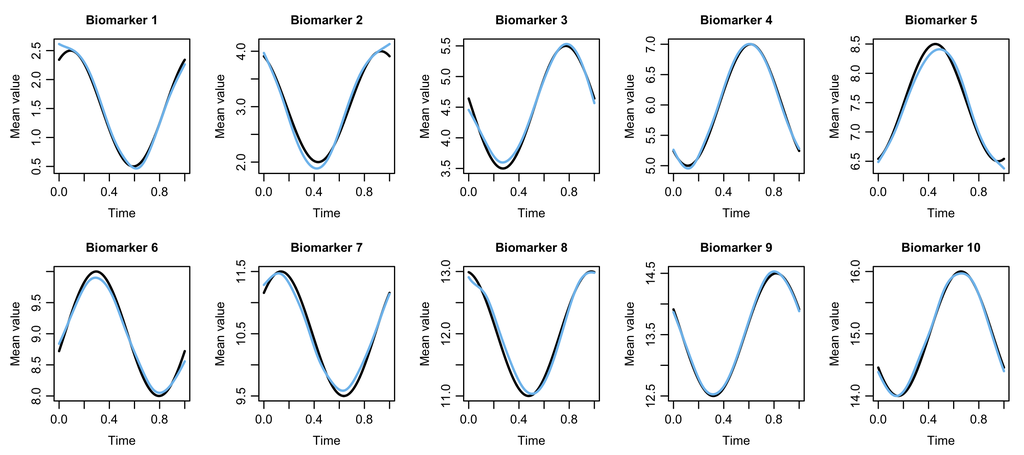

```r
op <- par(mfrow = c(2, 5), mar = c(3.6, 3.6, 2.6, 1), mgp = c(2.1, 0.7, 0), cex.main = 1)
for (j in 1:p) {
  yl <- range(c(sim$mu_g[[j]], fit$list_mu_hat[[j]]))
  plot(time_g, sim$mu_g[[j]], type = "l", lwd = 2, col = col_sim, ylim = yl,
       xlab = "Time", ylab = "Mean value", main = sprintf("Biomarker %d", j))
  lines(time_g, fit$list_mu_hat[[j]], lwd = 2, col = col_est)
}
```

```r
par(op)
```

## 5. Moving to real data

Replace Section 1 with your own `time_obs` and `Y` in the nested-list format. The model works on normalised time, so first rescale every observation time to `[0, 1]`, for example `t_scaled = (t - t_min) / (t_max - t_min)` with a common `t_min` and `t_max` across all subjects. The returned grid `fit$time_g` and all smooth estimates then live on `[0, 1]`, and you map them back to the original scale with `t = t_min + t_scaled * (t_max - t_min)`. Keep the over-specified fit of Section 2, and use Section 3 to decide how many factors and modes to retain. Then interpret `fit$B_hat`, `fit$ppi` and `fit$factor_ppi` directly and skip the truth alignment of Section 4.

The method scales to tens of thousands of biomarkers. For large `p`, raise `n_cpus` to use the built-in parallelism. For a small toy like this one, parallelism will not necessarily help and can even slow things down, because the per-worker communication overhead outweighs the work each worker does.

If a factor comes out empty, the cause is usually weak evidence relative to the sparsity prior. In order of impact: give each factor enough loading biomarkers (in the simulation, raise `a_om` relative to `b_om`), increase `N`, use `set_hyper(d_0 = 1)`, and set `bool_scale` correctly for your data.

## Reference

Jaoua, S., Temko, D. and Ruffieux, H. (2026). *A scalable Bayesian functional factor model for high-dimensional longitudinal molecular data.* [arXiv:2603.20844](https://arxiv.org/abs/2603.20844).